# R Lab: Simple Linear Regression

DSA 220 - Introduction to Data Science and Analytics

Author

Andrew DiLernia

Once completed, submit a zipped file (.zip) containing two total documents via Blackboard: a .qmd Quarto file and the corresponding HTML document.

## 1.

First, add a new code chunk containing the code below to load R packages for this lab.

```r
# Load necessary packages
library(tidyverse)
library(gt)
library(corrr)
library(ggthemes)
library(ggfortify)
library(broom)

# Setting default ggplot2 theme
theme_set(ggthemes::theme_few())
```

Load the state-level ACS data for 2021 into R using the code below.

```r
# Importing state-level U.S. ACS data for 2021
census_data <- read_csv("https://raw.githubusercontent.com/dilernia/STA418-518/main/Data/census_data_2008-2021.csv") |>
  dplyr::filter(!stringr::str_detect(county_state, pattern = ","), year == 2021) |>
  dplyr::mutate(perc_poverty = 100*prop_poverty,
                median_income_thousand = median_income / 1000)
```

## 2.

Reproduce the scatter plot below, including a straight-line of best fit showing the percent of people in poverty (`perc_poverty`) by the median income in thousands of dollars for each state (`median_income_thousand`).

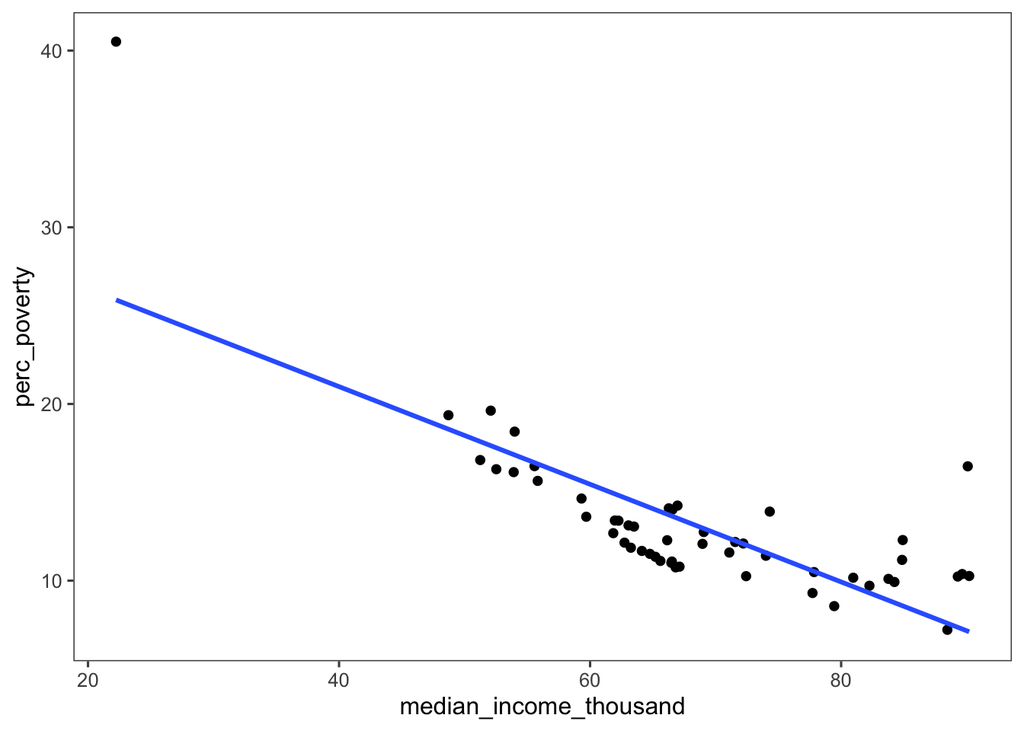

## 3.

Fit a simple linear regression model with median income in thousands of dollars as the predictor variable and percent poverty as the response variable.

## 4.

Reproduce the model output displayed below. *Hint*: pay careful attention to potential rounding in the table.

| term | estimate | std.error | statistic | p.value |
| --- | --- | --- | --- | --- |
| (Intercept) | 32.03 | 2.30 | 13.90 | 8.257394e-19 |
| median_income_thousand | −0.28 | 0.03 | −8.34 | 4.984794e-11 |

## 5.

Provide a statement of the estimated regression equation based on the model output.

## 6.

Provide the value of and interpret the estimated slope in context.

## 7.

Provide the value of and interpret the estimated intercept in context. Is this appropriate in this context? Why or why not?

## 8.

Create and display diagnostic plots for the simple linear regression model, including the Residuals vs Fitted plot, the Normal Q-Q plot, histogram of the residuals, Cook’s distance plot, and the Residuals vs Leverage plot.

## 9.

State and check if each assumption for fitting a simple linear regression model is met, providing specific evidence to support your conclusions from the R output obtained.

## 10.

Are there any influential points? If so, how many are there? Cite specific evidence to support your conclusion.

## 11.

Are there any outliers? If so, how many are there? Cite specific evidence to support your conclusion.

## 12.

Regardless of whether or not assumptions are met, formally state the hypotheses for testing if the regression slope is 0 or not.

## 13.

Provide the test statistic, p-value, and decision for this hypothesis test.

## 14.

Interpret the results of the hypothesis test in the context of the problem.